# The Atom Editor

Author

Affiliation

[Rodney Dyer](https://dyerlab.org)

Center for Environmental Studies

Published

June 20, 2018

[figure not shown]

Being new to the Windows platform, I’m on the look for a good text editor that can do the myriad of tasks that we do each day. Notepad is not an option, let’s be real. I’m looking for something that can be extended and has been designed from the bottom up for wrangling text and writing code. Ultimately, I would like something that is amenable to teaching both R and Python using a single interface. RStudio is great for R but sucks for Python. Juypter notebooks are clunky and toy-like.

Packages

Packages are extensions to the main editor that accomplish some function to make you life a bit easier. Here are some of the ones I find helpful. You can find packages and install them using Settings -> Install. Then search for the packages and hit the install button.

Minimap

If you have scripts and/or code that is longer than a single page (and who doesn’t) minimap provides a graphical depiction of your code on the right-hand side of the window to allow you to easily jump up and down the file. Here is an example on an R script.

[figure not shown]

Script

Script is a package that runs code in the editor directly. This means you can run individual lines as you develop and look at the output. Very helpful.

Themes

[figure not shown]

Once installed, you can change both the UI and the syntax colors.

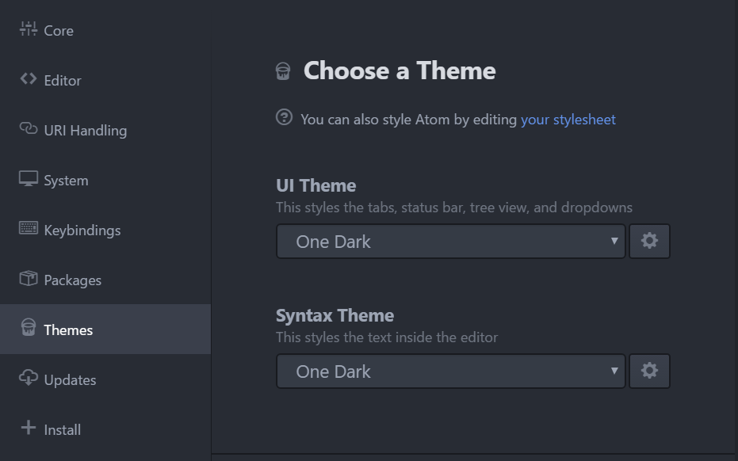

As I expand more into using Atom, I’ll add additional posts showing how I have configured it for use in my daily coding activities.